# **Introduction to Open Data Science, Exercise Set 3**

Logistic regression

This set consists of a few numbered exercises. Go to each exercise in turn and do as follows:

1. Read the brief description of the exercise.
2. Run the (possible) pre-exercise-code chunk.
3. Follow the instructions to fix the R code!

## 3.0 INSTALL THE REQUIRED PACKAGES FIRST!

One or more extra packages (in addition to `tidyverse`) will be needed below.

```r
# Select (with mouse or arrow keys) the install.packages("...") and
# run it (by Ctrl+Enter / Cmd+Enter):

# install.packages("boot")
# install.packages("readr")
```

## 3.1 More datasets

We will be combining, wrangling and analysing two new data sets retrieved from the [UCI Machine Learning Repository](https://archive.ics.uci.edu/ml/datasets.html), a great source for open data.

The data are from two identical questionnaires related to secondary school student alcohol consumption in Portugal. Read about the data and the variables [here](https://archive.ics.uci.edu/ml/datasets/Student+Performance).

R offers the convenient `paste()` function which makes it easy to combine characters. Let’s utilize it to get our hands on the data!

### Instructions

- Create and print out the object `url_math`.
- Create object `math` by reading the math class questionaire data from the web address defined in `url_math`.
- Create and print out `url_por`.
- Adjust the code: similarily to `url_math`, make `url_por` into a valid web address using `paste()` and the `url` object.
- Create object `por` by reading the Portuguese class questionaire data from the web address defined in `url_por`.
- Print out the names of the columns in both data sets.

Hint: - You can see the `paste()` functions help page with `?paste` or `help(paste)`

### R code

```r
# This is a code chunk in RStudio editor.
# Work with the exercise in this chunk, step-by-step. Fix the R code!

url <- "https://raw.githubusercontent.com/KimmoVehkalahti/Helsinki-Open-Data-Science/master/datasets/"

# web address for math class data
url_math <- paste(url, "student-mat.csv", sep = "/")

# print out the address
url_math
```

```
## [1] "https://raw.githubusercontent.com/KimmoVehkalahti/Helsinki-Open-Data-Science/master/datasets//student-mat.csv"
```

```r
# read the math class questionnaire data into memory
math <- read.table(url_math, sep = ";" , header = TRUE)

# web address for Portuguese class data
url_por <- paste(url, "student-por.csv", sep = "/")

# print out the address
url_por
```

```
## [1] "https://raw.githubusercontent.com/KimmoVehkalahti/Helsinki-Open-Data-Science/master/datasets//student-por.csv"
```

```r
# read the Portuguese class questionnaire data into memory
por <- read.table(url_por, sep = ";" , header = TRUE)

# look at the column names of both data sets
colnames(math); colnames(por)
```

```
##  [1] "school"     "sex"        "age"        "address"    "famsize"
##  [6] "Pstatus"    "Medu"       "Fedu"       "Mjob"       "Fjob"
## [11] "reason"     "guardian"   "traveltime" "studytime"  "failures"
## [16] "schoolsup"  "famsup"     "paid"       "activities" "nursery"
## [21] "higher"     "internet"   "romantic"   "famrel"     "freetime"
## [26] "goout"      "Dalc"       "Walc"       "health"     "absences"
## [31] "G1"         "G2"         "G3"
```

```
##  [1] "school"     "sex"        "age"        "address"    "famsize"
##  [6] "Pstatus"    "Medu"       "Fedu"       "Mjob"       "Fjob"
## [11] "reason"     "guardian"   "traveltime" "studytime"  "failures"
## [16] "schoolsup"  "famsup"     "paid"       "activities" "nursery"
## [21] "higher"     "internet"   "romantic"   "famrel"     "freetime"
## [26] "goout"      "Dalc"       "Walc"       "health"     "absences"
## [31] "G1"         "G2"         "G3"
```

## 3.2 Joining two datasets

There are multiple students who have answered both questionnaires in our two datasets. Unfortunately we do not have a single identification variable to identify these students. However, we can use a bunch of background questions together for identification.

Combining two data sets is easy if the data have a mutual identifier column or if a combination of mutual columns can be used as identifiers. (That’s not always the case.)

Here we’ll use `inner_join()` function from the dplyr package to combine the data - remember the [dplyr etc. cheatsheets!](https://www.rstudio.com/resources/cheatsheets/). This means that we’ll only keep the students who answered the questionnaire in both math and Portuguese classes.

### Instructions

- Access the dplyr library and create the objects `free_cols` and `join_cols`:
- The first one (`free_cols`) will be a vector of the names of the six columns that vary in the data sets, namely: failures, paid, absences, G1, G2, and G3.
- The other one (`join_cols`) will be a vector of the names of the rest of the variables; use the handy `setdiff()` function to obtain that vector, based on the `free_cols`.
- Adjust the code: define the argument `by` in the `inner_join()` function to join the `math` and `por` data frames. Use the columns defined in `join_cols`.
- Print out the column names of the joined data set.
- Adjust the code again: add the argument `suffix` to `inner_join()` and give it a vector of two strings: “.math” and “.por”.
- Join the data sets again and print out the new column names.
- Use the `glimpse()` function (from dplyr) to look at the joined data. Which data types are present?

Hints: - You can create a vector with `c()`. Comma will separate the values. - Remember to use quotes when creating string or character objects.

### R code

```r
# Work with the exercise in this chunk, step-by-step. Fix the R code!
# math and por data sets are available

# access the dplyr package
library(dplyr)
# give the columns that vary in the two data sets
free_cols <- c("failures", "paid", "absences", "G1", "G2", "G3")

# the rest of the columns are common identifiers used for joining the data sets
join_cols <- setdiff(colnames(por), free_cols)

# join the two data sets by the selected identifiers
math_por <- inner_join(math, por, by = join_cols, suffix = c(".math", ".por"))

# look at the column names of the joined data set
colnames(math_por)
```

```
##  [1] "school"        "sex"           "age"           "address"
##  [5] "famsize"       "Pstatus"       "Medu"          "Fedu"
##  [9] "Mjob"          "Fjob"          "reason"        "guardian"
## [13] "traveltime"    "studytime"     "failures.math" "schoolsup"
## [17] "famsup"        "paid.math"     "activities"    "nursery"
## [21] "higher"        "internet"      "romantic"      "famrel"
## [25] "freetime"      "goout"         "Dalc"          "Walc"
## [29] "health"        "absences.math" "G1.math"       "G2.math"
## [33] "G3.math"       "failures.por"  "paid.por"      "absences.por"
## [37] "G1.por"        "G2.por"        "G3.por"
```

```r
# glimpse at the joined data set

glimpse(math_por)
```

```
## Rows: 370
## Columns: 39
## $ school        <chr> "GP", "GP", "GP", "GP", "GP", "GP", "GP", "GP", "GP", "G…
## $ sex           <chr> "F", "F", "F", "F", "F", "M", "M", "F", "M", "M", "F", "…
## $ age           <int> 18, 17, 15, 15, 16, 16, 16, 17, 15, 15, 15, 15, 15, 15, …
## $ address       <chr> "U", "U", "U", "U", "U", "U", "U", "U", "U", "U", "U", "…
## $ famsize       <chr> "GT3", "GT3", "LE3", "GT3", "GT3", "LE3", "LE3", "GT3", …
## $ Pstatus       <chr> "A", "T", "T", "T", "T", "T", "T", "A", "A", "T", "T", "…
## $ Medu          <int> 4, 1, 1, 4, 3, 4, 2, 4, 3, 3, 4, 2, 4, 4, 2, 4, 4, 3, 3,…
## $ Fedu          <int> 4, 1, 1, 2, 3, 3, 2, 4, 2, 4, 4, 1, 4, 3, 2, 4, 4, 3, 2,…
## $ Mjob          <chr> "at_home", "at_home", "at_home", "health", "other", "ser…
## $ Fjob          <chr> "teacher", "other", "other", "services", "other", "other…
## $ reason        <chr> "course", "course", "other", "home", "home", "reputation…
## $ guardian      <chr> "mother", "father", "mother", "mother", "father", "mothe…
## $ traveltime    <int> 2, 1, 1, 1, 1, 1, 1, 2, 1, 1, 1, 3, 1, 2, 1, 1, 1, 3, 1,…
```

[output cut: 26 more lines]

## 3.3 The if-else structure

The `math_por` data frame now contains - in addition to the background variables used for joining `por` and `math` - two possibly different answers to the same questions for each student. To fix this, you’ll use programming to combine these ‘duplicated’ answers by either:

- taking the rounded average (**if** the two variables are numeric)
- simply choosing the first answer (**else**).

You’ll do this by using a combination of a `for`-loop and an `if`-`else` structure.

The `if()` function takes a single logical condition as an argument and performs an action only if that condition is true. `if` can then be combined with `else`, which handles the cases where the condition is false. Schematically:

```
if(condition) {
   do something
} else {
   do something else
}
```

### Instructions

- Print out the column names of `math_por` (use `colnames()`)
- Adjust the code: Create the data frame `alc` by selecting only the columns in `math_por` which were used for joining the two questionnaires. The names of those columns are available in the `join_cols` object.
- Print out the object that you created earlier for the columns that varied (`free_cols`).
- Execute the `for` loop (don’t mind the “change me!”).
- Take a `glimpse()` at the `alc` data frame. As you can see, it’s not ready yet…
- Adjust the code inside the `for` loop: if the first of the two selected columns is not numeric, add the first column to the `alc` data frame.
- Execute the modified `for` loop and `glimpse()` at the new data again.

Hint: - Inside the for-loop, use `first_col` in exchange for the “change me!”.

### R code

```r
# Work with the exercise in this chunk, step-by-step. Fix the R code!
# dplyr, math_por, join_by are available

# print out the column names of 'math_por'
colnames(math_por)
```

```
##  [1] "school"        "sex"           "age"           "address"
##  [5] "famsize"       "Pstatus"       "Medu"          "Fedu"
##  [9] "Mjob"          "Fjob"          "reason"        "guardian"
## [13] "traveltime"    "studytime"     "failures.math" "schoolsup"
## [17] "famsup"        "paid.math"     "activities"    "nursery"
## [21] "higher"        "internet"      "romantic"      "famrel"
## [25] "freetime"      "goout"         "Dalc"          "Walc"
## [29] "health"        "absences.math" "G1.math"       "G2.math"
## [33] "G3.math"       "failures.por"  "paid.por"      "absences.por"
## [37] "G1.por"        "G2.por"        "G3.por"
```

```r
# create a new data frame with only the joined columns
alc <- select(math_por, all_of(join_cols))

# print out the columns not used for joining (those that varied in the two data sets)
free_cols
```

```
## [1] "failures" "paid"     "absences" "G1"       "G2"       "G3"
```

```r
# for every column name not used for joining...
for(col_name in free_cols) {
  # select two columns from 'math_por' with the same original name
  two_cols <- select(math_por, starts_with(col_name))
  # select the first column vector of those two columns
  first_col <- select(two_cols, 1)[[1]]

  # then, enter the if-else structure!
  # if that first column vector is numeric...
  if(is.numeric(first_col)) {
    # take a rounded average of each row of the two columns and
    # add the resulting vector to the alc data frame
    alc[col_name] <- round(rowMeans(two_cols))
  } else { # else (if the first column vector was not numeric)...
    # add the first column vector to the alc data frame
    alc[col_name] <- first_col
  }
}

# glimpse at the new combined data
glimpse(alc)
```

```
## Rows: 370
## Columns: 33
## $ school     <chr> "GP", "GP", "GP", "GP", "GP", "GP", "GP", "GP", "GP", "GP",…
## $ sex        <chr> "F", "F", "F", "F", "F", "M", "M", "F", "M", "M", "F", "F",…
## $ age        <int> 18, 17, 15, 15, 16, 16, 16, 17, 15, 15, 15, 15, 15, 15, 15,…
## $ address    <chr> "U", "U", "U", "U", "U", "U", "U", "U", "U", "U", "U", "U",…
## $ famsize    <chr> "GT3", "GT3", "LE3", "GT3", "GT3", "LE3", "LE3", "GT3", "LE…
## $ Pstatus    <chr> "A", "T", "T", "T", "T", "T", "T", "A", "A", "T", "T", "T",…
## $ Medu       <int> 4, 1, 1, 4, 3, 4, 2, 4, 3, 3, 4, 2, 4, 4, 2, 4, 4, 3, 3, 4,…
## $ Fedu       <int> 4, 1, 1, 2, 3, 3, 2, 4, 2, 4, 4, 1, 4, 3, 2, 4, 4, 3, 2, 3,…
## $ Mjob       <chr> "at_home", "at_home", "at_home", "health", "other", "servic…
## $ Fjob       <chr> "teacher", "other", "other", "services", "other", "other", …
## $ reason     <chr> "course", "course", "other", "home", "home", "reputation", …
## $ guardian   <chr> "mother", "father", "mother", "mother", "father", "mother",…
## $ traveltime <int> 2, 1, 1, 1, 1, 1, 1, 2, 1, 1, 1, 3, 1, 2, 1, 1, 1, 3, 1, 1,…
```

[output cut: 20 more lines]

## 3.4 Mutations

Mutating a data frame means adding new variables as mutations of the existing ones. The `mutate()` function is also from the dplyr package, which belongs to the tidyverse packages. The tidyverse includes several packages that work well together, such as dplyr and ggplot2.

The tidyverse functions have a lot of similarities. For example, the first argument of the tidyverse functions is usually `data`. They also have other consistent features which makes them work well together and easy to use.

Let’s now create some new variables in the joined data set!

### Instructions

- Mutate `alc` by creating the new column `alc_use` by averaging weekday and weekend alcohol consumption.
- Draw a bar plot of `alc_use`.
- Define a new asthetic element to the bar plot of `alc_use` by defining `fill = sex`. Draw the plot again.
- Adjust the code: Mutate `alc` by creating a new column `high_use`, which is true if `alc_use` is greater than 2 and false otherwise.
- Initialize a ggplot object with `high_use` on the x-axis and then draw a bar plot.
- Add this element to the latter plot (using `+`): `facet_wrap("sex")`.

Hints: - Use the `>` operator to test if the values of a vector are greater than some value. - Add the argument `aes(x = high_use)` to the `ggplot()` function to initialize a plot with `high_use` on the x-axis.

### R code

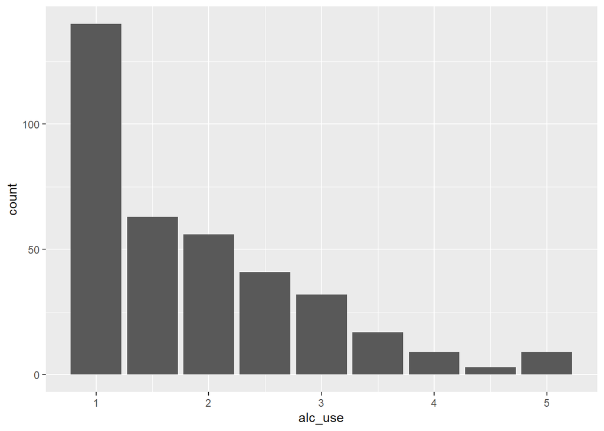

```r
# Work with the exercise in this chunk, step-by-step. Fix the R code!
# alc is available

# access the tidyverse packages dplyr and ggplot2
library(dplyr); library(ggplot2)

# define a new column alc_use by combining weekday and weekend alcohol use
alc <- mutate(alc, alc_use = (Dalc + Walc) / 2)

# initialize a plot of alcohol use
g1 <- ggplot(data = alc, aes(x = alc_use))

# define the plot as a bar plot and draw it
g1 + geom_bar()
```

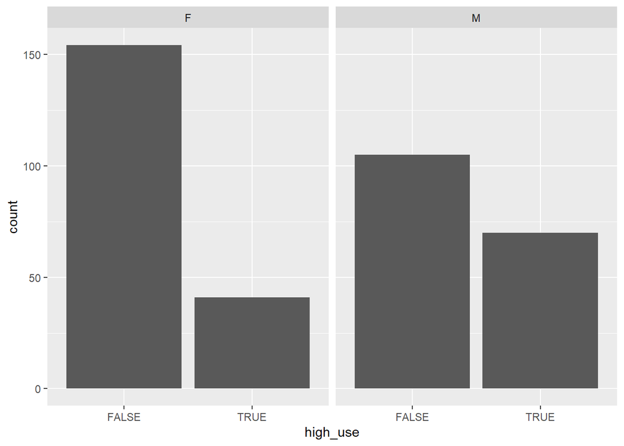

```r
# define a new logical column 'high_use'
alc <- mutate(alc, high_use = alc_use > 2)

# initialize a plot of 'high_use'
g2 <- ggplot(data = alc)

# draw a bar plot of high_use by sex
g2 <- ggplot(data = alc, aes(x = high_use))
g2 + geom_bar() + facet_wrap("sex")
```

## 3.5 So many plots

You are probably curious to find out how the distributions of some of the other variables in the data look like. Well, why don’t we visualize all of them!

You’ll also meet another new tidyverse toy, the pipe-operator: `%>%`.

The pipe (`%>%`) takes the result produced on its left side and uses it as the first argument in the function on its right side. Since the first argument of the tidyverse functions is usually `data`, this allows for some cool chaining of commands.

We’ll look at `%>%` more closely in the next exercise. But now, let’s draw some plots.

### Instructions

- Access the tidyverse libraries tidyr, dplyr and ggplot2
- Take a glimpse at the `alc` data
- Apply the `gather()` function on `alc` and then take a glimpse at the resulting data directly after, utilizing the pipe (`%>%`). What does gather do?
- Take a more detailed look similarly, but using the `View()` function, and browse the data. Can you now see better what happens when you use the `gather()` function?
- Draw a plot of each variable in the `alc` data by first changing the values into names-value pairs and then visualizing them with ggplot. Define the plots as bar plots by adding the element `geom_bar()`, (using `+`).

Hint: - Add the code `+ geom_bar()` to the line where the plots are drawn.

### R code

```r
# Work with the exercise in this chunk, step-by-step. Fix the R code!
# alc is available

# access the tidyverse libraries tidyr, dplyr, ggplot2
library(tidyr); library(dplyr); library(ggplot2)

# glimpse at the alc data
glimpse(alc)
```

```
## Rows: 370
## Columns: 35
## $ school     <chr> "GP", "GP", "GP", "GP", "GP", "GP", "GP", "GP", "GP", "GP",…
## $ sex        <chr> "F", "F", "F", "F", "F", "M", "M", "F", "M", "M", "F", "F",…
## $ age        <dbl> 18, 17, 15, 15, 16, 16, 16, 17, 15, 15, 15, 15, 15, 15, 15,…
## $ address    <chr> "U", "U", "U", "U", "U", "U", "U", "U", "U", "U", "U", "U",…
## $ famsize    <chr> "GT3", "GT3", "LE3", "GT3", "GT3", "LE3", "LE3", "GT3", "LE…
## $ Pstatus    <chr> "A", "T", "T", "T", "T", "T", "T", "A", "A", "T", "T", "T",…
## $ Medu       <dbl> 4, 1, 1, 4, 3, 4, 2, 4, 3, 3, 4, 2, 4, 4, 2, 4, 4, 3, 3, 4,…
## $ Fedu       <dbl> 4, 1, 1, 2, 3, 3, 2, 4, 2, 4, 4, 1, 4, 3, 2, 4, 4, 3, 2, 3,…
## $ Mjob       <chr> "at_home", "at_home", "at_home", "health", "other", "servic…
## $ Fjob       <chr> "teacher", "other", "other", "services", "other", "other", …
## $ reason     <chr> "course", "course", "other", "home", "home", "reputation", …
## $ guardian   <chr> "mother", "father", "mother", "mother", "father", "mother",…
## $ traveltime <dbl> 2, 1, 1, 1, 1, 1, 1, 2, 1, 1, 1, 3, 1, 2, 1, 1, 1, 3, 1, 1,…
```

[output cut: 22 more lines]

```r
# use gather() to gather columns into key-value pairs and then glimpse() at the resulting data
gather(alc) %>% glimpse
```

```
## Rows: 12,950
## Columns: 2
## $ key   <chr> "school", "school", "school", "school", "school", "school", "sch…
## $ value <chr> "GP", "GP", "GP", "GP", "GP", "GP", "GP", "GP", "GP", "GP", "GP"…
```

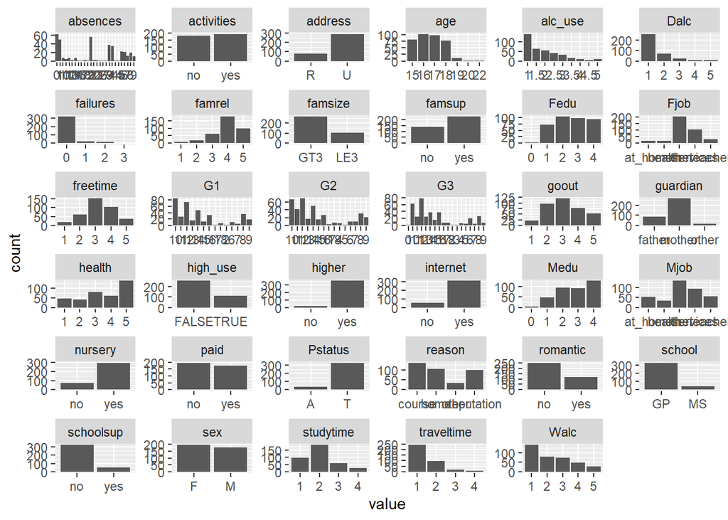

```r
# it may help to take a closer look by View() and browse the data
gather(alc) %>% View

# draw a bar plot of each variable
gather(alc) %>% ggplot(aes(value)) + facet_wrap("key", scales = "free") +
  geom_bar()
```

## 3.6 The pipe: summarising by group

The pipe operator, `%>%`, takes the result of the left-hand side and uses it as the first argument of the function on the right-hand side. For example:

```
1:10 %>% mean() # result: 5.5
```

The parentheses of the ‘target’ function (here mean) can be dropped unless one wants to specify more arguments for it.

```
1:10 %>% mean # result: 5.5
```

Chaining operations with the pipe is great fun, so let’s try it!

Utilizing the pipe, you’ll apply the functions `group_by()` and `summarise()` on your data. The first one splits the data to groups according to a grouping variable (a factor, for example). The latter can be combined with any summary function such as `mean()`, `min()`, `max()` to summarize the data.

### Instructions

- Access the tidyverse libraries dplyr and ggplot2
- Execute the sample code to see the counts of males and females in the data
- Adjust the code to calculate means of the grades of the students: inside `summarise()`, after the definition of `count`, define `mean_grade` by using `mean()` on the variable `G3`.
- Adjust the code: After `sex`, add `high_use` as another grouping variable. Execute the code again.

Hints: - Remember to separate inputs inside functions with a comma. Here the first input of `summarise` is `count`, and the second one should be `mean_grade`. - Also separate the grouping variables with a comma.

### R code

```r
# Work with the exercise in this chunk, step-by-step. Fix the R code!
# alc is available

1:10 %>% mean
```

```
## [1] 5.5
```

```r
# access the tidyverse libraries dplyr and ggplot2
library(dplyr); library(ggplot2)

# produce summary statistics by group
alc %>% group_by(sex) %>% summarise(count = n())
```

```
## # A tibble: 2 × 2
##   sex   count
##   <chr> <int>
## 1 F       195
## 2 M       175
```

```r
alc %>% summarise(count = n(), mean_grade = mean(G3))
```

```
## # A tibble: 1 × 2
##   count mean_grade
##   <int>      <dbl>
## 1   370       11.5
```

```r
alc %>% group_by(sex) %>% summarize(mean_grade = mean(G3))
```

```
## # A tibble: 2 × 2
##   sex   mean_grade
##   <chr>      <dbl>
## 1 F           11.5
## 2 M           11.5
```

```r
alc %>% group_by(sex) %>% summarise(count = n(), mean_grade = mean(G3))
```

```
## # A tibble: 2 × 3
##   sex   count mean_grade
##   <chr> <int>      <dbl>
## 1 F       195       11.5
## 2 M       175       11.5
```

```r
alc %>% group_by(sex, high_use) %>% summarise(count = n(), mean_grade = mean(G3))
```

[output not shown]

```
## # A tibble: 4 × 4
## # Groups:   sex [2]
##   sex   high_use count mean_grade
##   <chr> <lgl>    <int>      <dbl>
## 1 F     FALSE      154       11.4
## 2 F     TRUE        41       11.8
## 3 M     FALSE      105       12.3
## 4 M     TRUE        70       10.3
```

```r
alc %>%
  group_by(sex, high_use) %>%
  tally() %>%
  spread(high_use, n)
```

```
## # A tibble: 2 × 3
## # Groups:   sex [2]
##   sex   `FALSE` `TRUE`
##   <chr>   <int>  <int>
## 1 F         154     41
## 2 M         105     70
```

## 3.7 Box plots by groups

[Box plots](https://en.wikipedia.org/wiki/Box_plot) are an excellent way of displaying and comparing distributions. A box plot visualizes the 25th, 50th and 75th percentiles (the box), the typical range (the whiskers) and the outliers of a variable.

The whiskers extending from the box can be computed by several techniques. The default (in base R and ggplot) is to extend them to reach to a data point that is no more than 1.5*IQR away from the box, where IQR is the inter quartile range defined as

`IQR = 75th percentile - 25th percentile`

Values outside the whiskers can be considered as outliers, unusually distant observations. For more information on IQR, see [wikipedia](https://en.wikipedia.org/wiki/Interquartile_range), for example.

### Instructions

- Initialize a plot of student grades (`G3`), with `high_use` grouping the grade distributions on the x-axis. Draw the plot as a box plot.
- Add an aesthetic element to the plot by defining `col = sex` inside `aes()`
- Define a similar (box) plot of the variable `absences` grouped by `high_use` on the x-axis and the aesthetic `col = sex`.
- Add a main title to the last plot with `ggtitle("title here")`. Use “Student absences by alcohol consumption and sex” as a title, for example.
- Does high use of alcohol have a connection to school absences?

Hints: - In ggplot, you can add stuff to the initialized plot with the `+` operator, e.g. `+ ylab("text here")`. Same goes for titles.

### R code

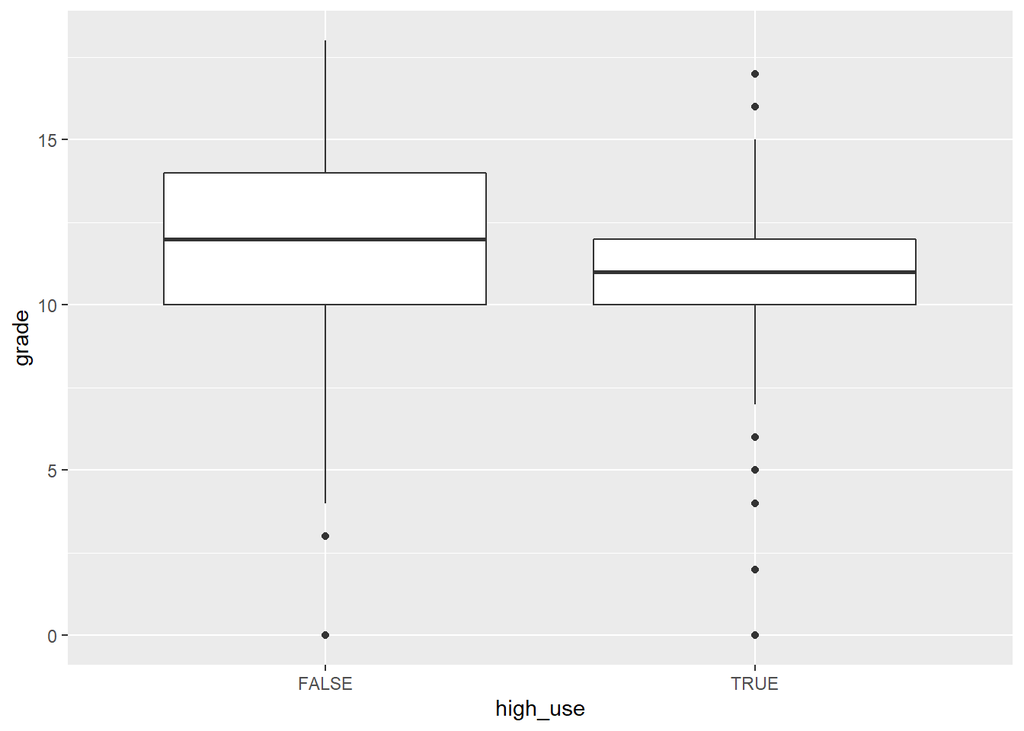

```r
# Work with the exercise in this chunk, step-by-step. Fix the R code!
library(ggplot2)

# initialize a plot of high_use and G3
g1 <- ggplot(alc, aes(x = high_use, y = G3))

# define the plot as a boxplot and draw it
g1 + geom_boxplot() + ylab("grade")
```

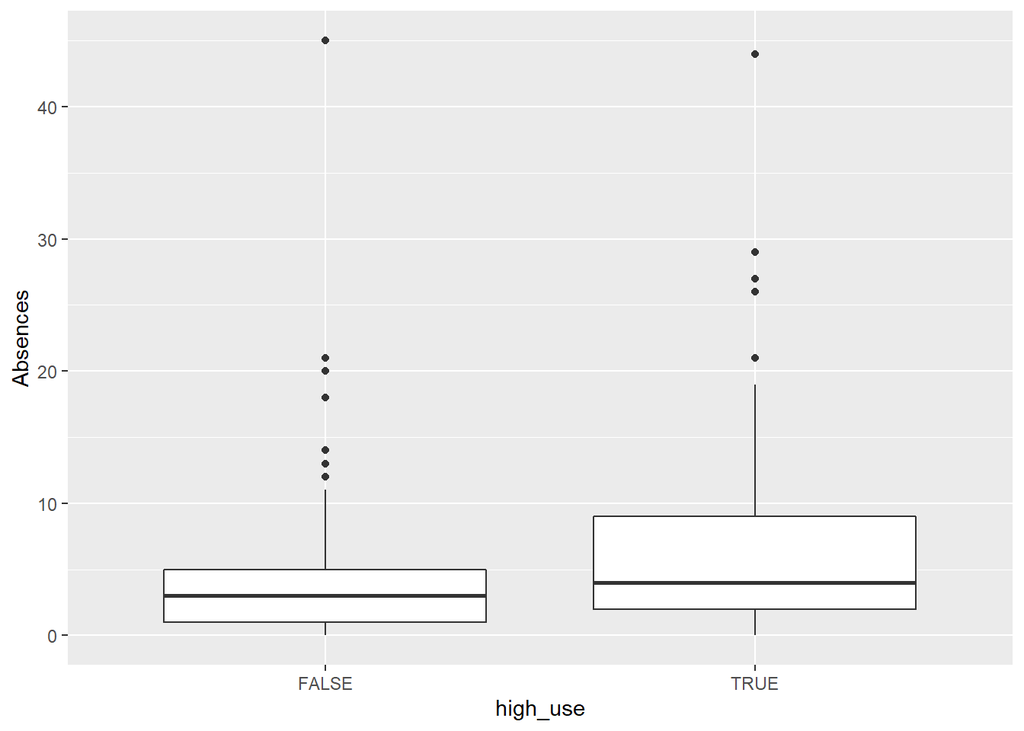

```r
# initialize a plot of high_use and absences
g2 <- ggplot(alc, aes(x = high_use, y = absences))

# define the plot as a box plot and draw it
g2 + geom_boxplot() + ylab("Absences")
```

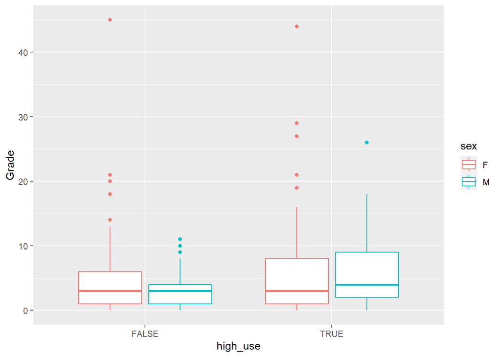

```r
g3 <- ggplot(alc, aes(x = high_use, y = absences, col = sex))
g3 + geom_boxplot() + ylab("Grade")
```

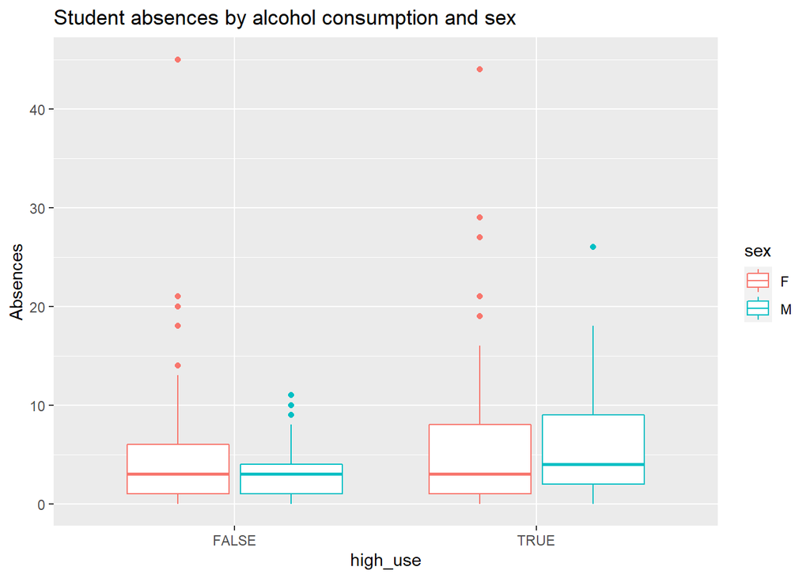

```r
g4 <- ggplot(alc, aes(x = high_use, y = absences, col = sex))
g4 + geom_boxplot() + ylab("Absences") + ggtitle("Student absences by alcohol consumption and sex")
```

## 3.8 Learning a logistic regression model

We will now use [logistic regression](https://en.wikipedia.org/wiki/Logistic_regression) to identify factors related to higher than average student alcohol consumption. You will also attempt to learn to identify (predict) students who consume high amounts of alcohol using background variables and school performance.

Because logistic regression can be used to classify observations into one of two groups (by giving the group probability) it is a [binary classification](https://en.wikipedia.org/wiki/Binary_classification) method. You will meet more classification methods in the next week’s exercises.

### Instructions

- Use `glm()` to fit a logistic regression model with `high_use` as the target variable and `failures` and `absences` as the predictors.
- Print out a summary of the model.
- Add another explanatory variable to the model after absences: ‘sex’. Repeat the above.
- Use `coef()` on the model object to print out the coefficients of the model.

Hint: - Use the `summary()` function to print out a summary.

### R code

```r
# Work with the exercise in this chunk, step-by-step. Fix the R code!
# alc is available

# find the model with glm()
m <- glm(high_use ~ failures + absences, data = alc, family = "binomial")

# print out a summary of the model
summary(m)
```

```
##
## Call:
## glm(formula = high_use ~ failures + absences, family = "binomial",
##     data = alc)
##
## Deviance Residuals:
##     Min       1Q   Median       3Q      Max
## -2.2281  -0.7747  -0.6937   1.2043   1.7939
##
## Coefficients:
##             Estimate Std. Error z value Pr(>|z|)
## (Intercept) -1.38590    0.16717  -8.290  < 2e-16 ***
## failures     0.64059    0.20050   3.195 0.001398 **
## absences     0.08402    0.02306   3.644 0.000269 ***
## ---
## Signif. codes:  0 '***' 0.001 '**' 0.01 '*' 0.05 '.' 0.1 ' ' 1
##
## (Dispersion parameter for binomial family taken to be 1)
##
##     Null deviance: 452.04  on 369  degrees of freedom
## Residual deviance: 423.97  on 367  degrees of freedom
## AIC: 429.97
##
## Number of Fisher Scoring iterations: 4
```

```r
# print out the coefficients of the model
coef(m)
```

```
## (Intercept)    failures    absences
## -1.38589606  0.64059042  0.08401658
```

```r
# Model with sex

m2 <- glm(high_use ~ failures + absences + sex, data = alc, family = "binomial")

# print out a summary of the model
summary(m2)
```

```
##
## Call:
## glm(formula = high_use ~ failures + absences + sex, family = "binomial",
##     data = alc)
##
## Deviance Residuals:
##     Min       1Q   Median       3Q      Max
## -2.1550  -0.8430  -0.5889   1.0328   2.0374
##
## Coefficients:
##             Estimate Std. Error z value Pr(>|z|)
## (Intercept) -1.94150    0.23129  -8.394  < 2e-16 ***
## failures     0.59759    0.20698   2.887  0.00389 **
## absences     0.09245    0.02323   3.979 6.91e-05 ***
## sexM         0.99731    0.24725   4.034 5.49e-05 ***
## ---
## Signif. codes:  0 '***' 0.001 '**' 0.01 '*' 0.05 '.' 0.1 ' ' 1
##
## (Dispersion parameter for binomial family taken to be 1)
##
##     Null deviance: 452.04  on 369  degrees of freedom
## Residual deviance: 406.99  on 366  degrees of freedom
## AIC: 414.99
##
## Number of Fisher Scoring iterations: 4
```

```r
# print out the coefficients of the model
coef(m2)
```

```
## (Intercept)    failures    absences        sexM
## -1.94149584  0.59759293  0.09245138  0.99731318
```

## 3.9 From coefficients to odds ratios

From the fact that the computational target variable in the logistic regression model is the log of odds, it follows that applying the exponent function to the modeled values gives the odds:

$$\exp \left( log\left( \frac{p}{1 - p}
\right) \right) = \frac{p}{1 - p}.$$

For this reason, the exponents of the coefficients of a logistic regression model can be interpreted as odds ratios between a unit change (vs. no change) in the corresponding explanatory variable.

### Instructions

- Use `glm()` to fit a logistic regression model.
- Creat the object `OR`: Use `coef()` on the model object to extract the coefficients of the model and then apply the `exp` function on the coefficients.
- Use `confint()` on the model object to compute confidence intervals for the coefficients. Exponentiate the values and assign the results to the object `CI`. (R does this quite fast, despite the “Waiting..” message)
- Combine and print out the odds ratios and their confidence intervals. Which predictor has the widest interval? Does any of the intervals contain 1 and why would that matter?

Hints: - You can get the confidence intervals with `confint(*model_object*)` - The logistic regression model is saved in the object `m`. - `coef(m) %>% exp` is the same as `exp( coef(m) )` - You get odds ratios by exponentiating the logistic regression coefficients.

### R code

```r
# Work with the exercise in this chunk, step-by-step. Fix the R code!
# alc is available

# find the model with glm()
m <- glm(high_use ~ failures + absences + sex, data = alc, family = "binomial")

summary(m)
```

```
##
## Call:
## glm(formula = high_use ~ failures + absences + sex, family = "binomial",
##     data = alc)
##
## Deviance Residuals:
##     Min       1Q   Median       3Q      Max
## -2.1550  -0.8430  -0.5889   1.0328   2.0374
##
## Coefficients:
##             Estimate Std. Error z value Pr(>|z|)
## (Intercept) -1.94150    0.23129  -8.394  < 2e-16 ***
## failures     0.59759    0.20698   2.887  0.00389 **
## absences     0.09245    0.02323   3.979 6.91e-05 ***
## sexM         0.99731    0.24725   4.034 5.49e-05 ***
## ---
## Signif. codes:  0 '***' 0.001 '**' 0.01 '*' 0.05 '.' 0.1 ' ' 1
##
## (Dispersion parameter for binomial family taken to be 1)
##
##     Null deviance: 452.04  on 369  degrees of freedom
## Residual deviance: 406.99  on 366  degrees of freedom
## AIC: 414.99
##
## Number of Fisher Scoring iterations: 4
```

```r
# compute odds ratios (OR)
OR <- coef(m) %>% exp

# compute confidence intervals (CI)
CI <- confint(m) %>% exp
# print out the odds ratios with their confidence intervals
cbind(OR, CI)
```

```
##                    OR      2.5 %    97.5 %
## (Intercept) 0.1434892 0.08940913 0.2219242
## failures    1.8177381 1.21997630 2.7642305
## absences    1.0968598 1.05041937 1.1508026
## sexM        2.7109881 1.67967829 4.4367282
```

## 3.10 Binary predictions (1)

When you have a linear model, you can make predictions. A very basic question is, of course, how well does our model actually predict the target variable. Let’s take a look!

The `predict()` function can be used to make predictions with a model object. If `predict()` is not given any new data, it will use the data used for finding (fitting, leaning, training) the model to make predictions.

In the case of a binary response variable, the ‘type’ argument of `predict()` can be used to get the predictions as probabilities (instead of log of odds, the default).

### Instructions

- Fit the logistic regression model with `glm()`.
- Create object `probabilities` by using `predict()` on the model object.
- Mutate the alc data: add a column ‘probability’ with the predicted probabilities.
- Mutate the data again: add a column ‘prediction’ which is true if the value of ‘probability’ is greater than 0.5.
- Look at the first ten observations of the data, along with the predictions.
- Use `table()` to create a cross table of the columns ‘high_use’ versus ‘prediction’ in `alc`. This is sometimes called a ’confusion matrix`.

Hints: - Remember to use the [dplyr cheat sheet](https://www.rstudio.com/wp-content/uploads/2015/02/data-wrangling-cheatsheet.pdf) by RStudio - The `$` sign can be used to access columns of a data frame

### R code

```r
# Work with the exercise in this chunk, step-by-step. Fix the R code!
# alc is available

# fit the model
m <- glm(high_use ~ failures + absences + sex, data = alc, family = "binomial")

# predict() the probability of high_use
probabilities <- predict(m, type = "response")

library(dplyr)
# add the predicted probabilities to 'alc'
alc <- mutate(alc, probability = probabilities)

# use the probabilities to make a prediction of high_use
alc <- mutate(alc, prediction = probability > 0.5)

# see the last ten original classes, predicted probabilities, and class predictions
select(alc, failures, absences, sex, high_use, probability, prediction) %>% tail(10)
```

```
## # A tibble: 10 × 6
##    failures absences sex   high_use probability prediction
##       <dbl>    <dbl> <chr> <lgl>          <dbl> <lgl>
##  1        0        3 M     FALSE          0.339 FALSE
##  2        1        0 M     FALSE          0.414 FALSE
##  3        1        7 M     TRUE           0.575 TRUE
##  4        0        1 F     FALSE          0.136 FALSE
##  5        0        6 F     FALSE          0.200 FALSE
##  6        1        2 F     FALSE          0.239 FALSE
##  7        0        2 F     FALSE          0.147 FALSE
##  8        0        3 F     FALSE          0.159 FALSE
##  9        0        4 M     TRUE           0.360 FALSE
## 10        0        2 M     TRUE           0.319 FALSE
```

```r
# tabulate the target variable versus the predictions
table(high_use = alc$high_use, prediction = alc$prediction)
```

```
##         prediction
## high_use FALSE TRUE
##    FALSE   252    7
##    TRUE     78   33
```

## 3.11 Binary predictions (2)

Let’s continue to explore the predictions of our model.

### Instructions

- Initialize the ggplot object and define `probability` as the x axis and `high_use` as the y axis.
- Use `geom_point()` to draw the plot.
- Add the aesthetic element `col = prediction` and draw the plot again.
- Use `table()` to create a cross table of ‘high_use’ versus ‘prediction’
- Adjust the code: Use `%>%` to apply the `prop.table()` function on the output of `table()`
- Adjust the code: Use `%>%` to apply the `addmargins()` function on the output of `prop.table()`

Hint: - Recall that the pipe (`%>%`) assigns the output of the function on its left side to the function on its right side. The idea is to chain the three commands `table`, `prop.table` and `addmargins` (in that order).

### R code

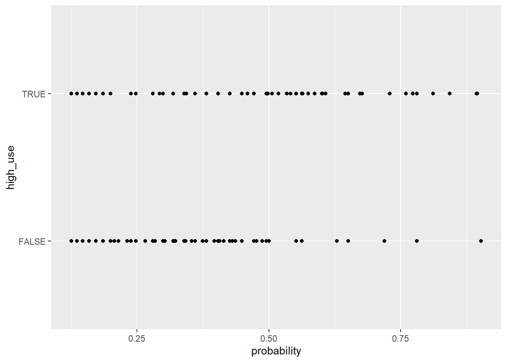

```r
# Work with the exercise in this chunk, step-by-step. Fix the R code!
# alc is available

# access dplyr and ggplot2
library(dplyr); library(ggplot2)

# initialize a plot of 'high_use' versus 'probability' in 'alc'
g <- ggplot(alc, aes(x = probability, y = high_use))

# define the geom as points and draw the plot
g1 <- g + geom_point()
g1
```

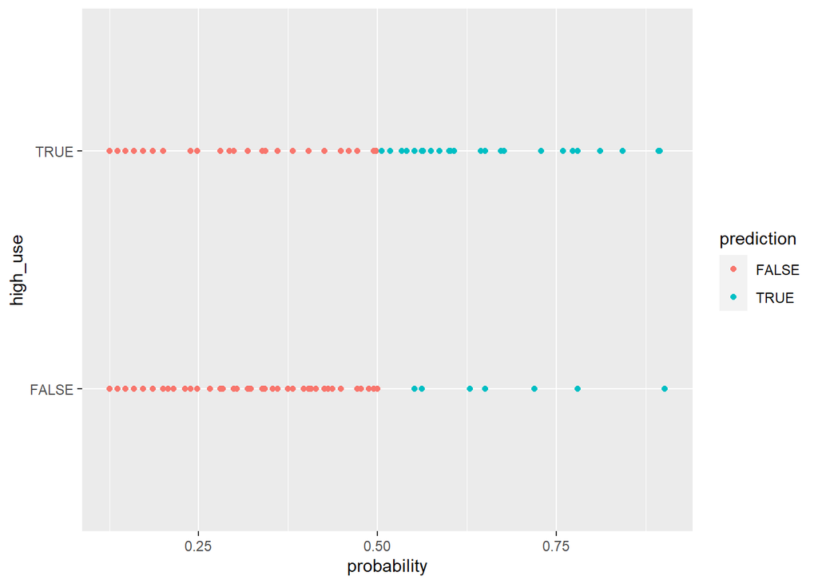

```r
# With col = prediction
g <- ggplot(alc, aes(x = probability, y = high_use, col = prediction))
g1 <- g + geom_point()
g1
```

```r
# tabulate the target variable versus the predictions
tab <- table(high_use = alc$high_use, prediction = alc$prediction)
tab
```

```
##         prediction
## high_use FALSE TRUE
##    FALSE   252    7
##    TRUE     78   33
```

```r
# tabulate the target variable versus the probabilities of predictions
table(high_use = alc$high_use, prediction = alc$prediction) %>% prop.table()
```

```
##         prediction
## high_use      FALSE       TRUE
##    FALSE 0.68108108 0.01891892
##    TRUE  0.21081081 0.08918919
```

```r
protab <- prop.table(tab)
protab
```

```
##         prediction
## high_use      FALSE       TRUE
##    FALSE 0.68108108 0.01891892
##    TRUE  0.21081081 0.08918919
```

```r
#Add all margin totals
table(high_use = alc$high_use, prediction = alc$prediction) %>% prop.table() %>% addmargins()
```

```
##         prediction
## high_use      FALSE       TRUE        Sum
##    FALSE 0.68108108 0.01891892 0.70000000
##    TRUE  0.21081081 0.08918919 0.30000000
##    Sum   0.89189189 0.10810811 1.00000000
```

```r
addmarg <- addmargins(protab)
addmarg
```

```
##         prediction
## high_use      FALSE       TRUE        Sum
##    FALSE 0.68108108 0.01891892 0.70000000
##    TRUE  0.21081081 0.08918919 0.30000000
##    Sum   0.89189189 0.10810811 1.00000000
```

## 3.12 Accuracy and loss functions

A simple measure of performance in binary classification is accuracy: the average number of correctly classified observations.

Classification methods such as logistic regression aim to (approximately) minimize the incorrectly classified observations. The mean of incorrectly classified observations can be thought of as a penalty (loss) function for the classifier. Less penalty = good.

Since we know how to make predictions with our model, we can also compute the average number of incorrect predictions.

### Instructions

- Define the loss function `loss_func`
- Execute the call to the loss function with `prob = 0`, meaning you define the probability of `high_use` as zero for each individual. What is the interpretation of the resulting proportion?
- Adjust the code: change the `prob` argument in the loss function to `prob = 1`. What kind of a prediction does this equal to? What is the interpretation of the resulting proportion?
- Adjust the code again: change the `prob` argument by giving it the prediction probabilities in `alc` (the column `probability`). What is the interpretation of the resulting proportion?

Hints: - Select the whole code of `loss_func` to execute it. - You can access the `probability` column in `alc` by using the `$`-mark.

### R code

```r
# Work with the exercise in this chunk, step-by-step. Fix the R code!
# the logistic regression model m and dataset alc with predictions are available

# define a loss function (mean prediction error)
loss_func <- function(class, prob) {
  n_wrong <- abs(class - prob) > 0.5
  mean(n_wrong)
}

# call loss_func to compute the average number of wrong predictions in the (training) data
loss_func(class = alc$high_use, prob = 0)
```

```
## [1] 0.3
```

```r
loss_func(class = alc$high_use, prob = 1)
```

```
## [1] 0.7
```

```r
loss_func(class = alc$high_use, prob = alc$probability)
```

```
## [1] 0.2297297
```

## 3.13 Cross-validation

Cross-validation is a method of testing a predictive model on unseen data. In cross-validation, the value of a penalty (loss) function (mean prediction error) is computed on data not used for finding the model. Low value = good.

Cross-validation gives a good estimate of the actual predictive power of the model. It can also be used to compare different models or classification methods.

### Instructions

- Define the loss function `loss_func` and compute the mean prediction error for the training data: The `high_use` column in `alc` is the target and the `probability` column has the predictions.
- Perform leave-one-out cross-validation and print out the mean prediction error for the testing data. (`nrow(alc)` gives the observation count in `alc` and using `K = nrow(alc)` defines the leave-one-out method. The `cv.glm` function from the ‘boot’ library computes the error and stores it in `delta`. See `?cv.glm` for more information.)
- Adjust the code: Perform 10-fold cross validation. Print out the mean prediction error for the testing data. Is the prediction error higher or lower on the testing data compared to the training data? Why?

Hint: - The `K` argument in `cv.glm` tells how many folds you will have.

### R code

```r
# Work with the exercise in this chunk, step-by-step. Fix the R code!
# the logistic regression model m and dataset alc (with predictions) are available

# define a loss function (average prediction error)
loss_func <- function(class, prob) {
  n_wrong <- abs(class - prob) > 0.5
  mean(n_wrong)
}

# compute the average number of wrong predictions in the (training) data
loss_func(class = alc$high_use, prob = alc$probability)
```

```
## [1] 0.2297297
```

```r
# K-fold cross-validation
library(boot)
cv <- cv.glm(data = alc, cost = loss_func, glmfit = m, K = nrow(alc))

# average number of wrong predictions in the cross validation
cv$delta[1]
```

```
## [1] 0.2405405
```

```r
library(boot)
cv <- cv.glm(data = alc, cost = loss_func, glmfit = m, K = 10)

# average number of wrong predictions in the cross validation
cv$delta[1]
```

```
## [1] 0.2405405
```

```r
?cv.glm
```

```
## starting httpd help server ... done
```

**GOOD JOB!**